# ToothGrowth: Examining the Effect of Vitamin C Supplementation on Odontoblast Length

## Executive Summary

Here, we examine the effect of vitamin supplementation on a proxy measure of tooth growth in guinea pigs. Both sources of vitamin C tested, orange juice and ascorbic acid, dose-dependently increased odontoblast length. Although at lower vitamin C-equivalent doses orange juice was more effective than ascorbic acid at increasing odontoblast length, both supplements were equally effective at the highest dose.

## Explanatory Data Analysis and Basic Dataset Summary

After loading the ToothGrowth dataset and ggplot2 for visualization, let’s examine the data using the str function.

```r
str(ToothGrowth)
```

```
'data.frame':   60 obs. of  3 variables:
 $ len : num  4.2 11.5 7.3 5.8 6.4 10 11.2 11.2 5.2 7 ...
 $ supp: Factor w/ 2 levels "OJ","VC": 2 2 2 2 2 2 2 2 2 2 ...
 $ dose: num  0.5 0.5 0.5 0.5 0.5 0.5 0.5 0.5 0.5 0.5 ...
```

We see a simple data frame with 3 variables. According to the annotation of this dataset, ‘len’ is the length of odontoblasts cells of 60 guinea pigs at 3 dose levels (dose) and 2 delivery methods (supp), n = 10 each. We can further see the distribution of the variables using the summary function.

```r
summary(ToothGrowth)
```

```
      len        supp         dose
 Min.   : 4.20   OJ:30   Min.   :0.500
 1st Qu.:13.07   VC:30   1st Qu.:0.500
 Median :19.25           Median :1.000
 Mean   :18.81           Mean   :1.167
 3rd Qu.:25.27           3rd Qu.:2.000
 Max.   :33.90           Max.   :2.000
```

```r
unique(ToothGrowth$dose)
```

```
[1] 0.5 1.0 2.0
```

As seen above, ‘supp’ is a factor variable taking one of 2 forms, OJ (orange juice) or VC (ascorbic acid, also known as vitamin C). Although specific doses were administered (0.5, 1, and 2 mg/day), ‘dose’ is a continuous numeric variable. ‘Len’ ranges from 4.2 microns up to 33.9 microns, with a mean of 18.8 and median of 19.25. Let’s plot the data and see how the different experimental conditions affected length.

Importantly - this is dose-response data, which is traditionally visualized on a semi-log plot; we can tell ggplot2 to log10 transform our data.

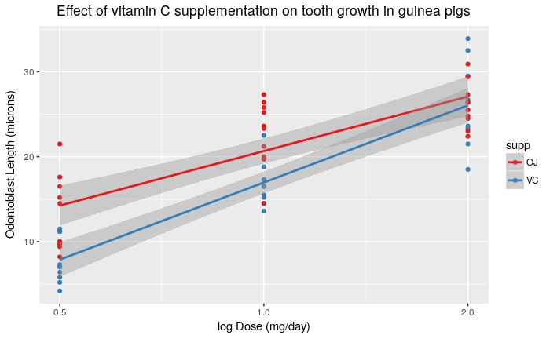

```r
ggplot(data = ToothGrowth, mapping = aes(x = dose, y = len, color = supp)) +
    scale_x_log10(breaks = c(0.5, 1, 2)) +
    scale_colour_brewer(palette = "Set1") +
    geom_point() +
    geom_smooth(method = "lm") +
    labs(title = "Effect of vitamin C supplementation on tooth growth in guinea pigs", x = "log Dose (mg/day)", y = "Odontoblast Length (microns)") +
    theme(plot.title = element_text(hjust = 0.5))
```

## Statistical Inference

Generally, dose-response data is fit using a probit model or using nonlinear regression; however, with so few points and the assignment instructions, we will use a simple linear model. Assuming we are between 15% and 85% of maximal response, this linear fit is a fair representation as the sigmoidal curve is roughly linear in this range.

```r
tooth_fit <- lm(len ~ log(dose)*supp, data = ToothGrowth)
tooth_fit
```

```
Call:
lm(formula = len ~ log(dose) * supp, data = ToothGrowth)

Coefficients:
     (Intercept)         log(dose)            suppVC  log(dose):suppVC
          20.663             9.255            -3.700             3.845
```

```r
anova(tooth_fit)
```

```
Analysis of Variance Table

Response: len
               Df  Sum Sq Mean Sq  F value    Pr(>F)
log(dose)       1 2400.95 2400.95 173.5134 < 2.2e-16 ***
supp            1  205.35  205.35  14.8404 0.0003033 ***
log(dose):supp  1   71.02   71.02   5.1327 0.0273658 *
Residuals      56  774.89   13.84
---
Signif. codes:  0 ‘***’ 0.001 ‘**’ 0.01 ‘*’ 0.05 ‘.’ 0.1 ‘ ’ 1
```